# HW2

Wenlin Ye

3/4/2023

# Step-0 Synopsis

This dataset consists of medical records for patients at a University hospital outpatient clinic specializing in collagen diseases. The data is divided into three tables that can be connected using patient ID numbers. The first table contains basic patient information and diagnosis details, the second table provides information on examination dates, lab results, and thrombosis occurrences, and the third table includes a comprehensive list of laboratory test results. The main goals of this study are to identify patterns for detecting and predicting thrombosis, find temporal patterns related to thrombosis and collagen diseases, and classify collagen diseases accurately.

# Step-1: Initial questions

1.Can we identify specific laboratory tests or combinations of tests that are strongly associated with thrombosis, and can these tests be used to predict the likelihood of thrombosis in patients?

2.Are there any temporal patterns in laboratory test results or symptom onset that are specific to certain collagen diseases, and can these patterns be used to improve the accuracy of disease classification?

3.How does the age and sex of patients with collagen diseases impact their laboratory test results, and are there any differences in the test results or disease severity between male and female patients in different age groups?

How do different demographic factors, such as age and sex, affect the prevalence of thrombosis in patients with collagen diseases? Are there any specific laboratory test results (e.g., ANA, aCL IgG, or aCL IgM) that show a strong correlation with the occurrence of thrombosis in these patients? Do specific collagen disease subtypes (e.g., C3 C4) exhibit unique temporal patterns in lab results that can help differentiate them from other subtypes?

# Step-2: Data Ingestion, cleaning, and munging

```r
library(tidyverse)
library(lubridate)
library(snakecase)
library(dplyr)

# Load the three datasets
tsumoto_a <- read.csv('TSUMOTO_A.csv')
tsumoto_b <- read.csv('TSUMOTO_B.csv')
tsumoto_c <- read.csv('TSUMOTO_C.csv', fileEncoding = "latin1")

#Clean the column names by converting them to snake_case format
colnames(tsumoto_a) <- to_snake_case(colnames(tsumoto_a))
colnames(tsumoto_b) <- to_snake_case(colnames(tsumoto_b))
colnames(tsumoto_c) <- to_snake_case(colnames(tsumoto_c))


#Join the three tables using the ID column

combined_data <- tsumoto_a %>%
  full_join(tsumoto_b, by = "id") %>%
  full_join(tsumoto_c, by = "id")



tidy_data <- combined_data %>%
  distinct() %>%
  drop_na(id)%>%
  drop_na(examination_date) # Optionally, remove rows with missing IDs



#subset dataset for required columns of analysis
tidy_data <- subset(tidy_data , select=c("id", "sex", "birthday", "diagnosis.x", "examination_date", "a_cl_ig_g", "a_cl_ig_m", "ana", "ana_pattern", "diagnosis.y", "thrombosis",'date'))


# Replace blank values
tidy_data <- tidy_data %>%
  mutate_all(~replace(., . == "", NA))

#keep the most recent row for each ID
tidy_data <- tidy_data %>%
  arrange(desc(date)) %>%
  distinct(id, .keep_all = TRUE)

tidy_data <- select(tidy_data, -date)

# remove rows where NA still exists
tidy_data <- na.omit(tidy_data)


write.csv(tidy_data, file = "tidy_data.csv", row.names = FALSE)
tidy_data
```

```
##          id sex   birthday                diagnosis.x examination_date
## 1   2899259   F  8/15/1972                        SLE         8/9/1995
## 2   5367812   F  2/14/1976            RA, paniculitis        8/24/1995
## 3   5385629   F   2/1/1972                       MCTD        9/25/1995
## 4   5437753   F  1/20/1980                        SLE        1/25/1996
## 5   5440870   F   8/8/1984                        SJS         2/1/1996
## 6   5472013   F   4/9/1985                   SLE, APS        4/16/1996
## 7   5492536   F 11/20/1954                         RA        5/27/1996
## 8   5554733   M 12/24/1966            DM, Sarcoidosis        10/4/1996
## 12  2340311   F 12/12/1966                        SLE        4/18/1995
## 15  5392386   F  8/11/1972                        SLE       10/11/1995
## 16  5512586   M 11/20/1987                        APS        9/30/1997
## 17  5626146   F   2/1/1955                        APS         2/3/1998
## 18  5676734   F   5/5/1972                        SJS        7/22/1997
## 20  1180510   F  6/17/1974                    Raynaud        6/10/1996
```

[output cut: 577 more lines]

# Step-3: Exploratory Visual Analysis

```r
# Load the tidy dataset
tidy_data <- read.csv("tidy_data.csv", header = TRUE)

# Print the structure of the dataset
str(tidy_data)
```

```
## 'data.frame':    295 obs. of  11 variables:
##  $ id              : int  2899259 5367812 5385629 5437753 5440870 5472013 5492536 5554733 2340311 5392386 ...
##  $ sex             : chr  "F" "F" "F" "F" ...
##  $ birthday        : chr  "8/15/1972" "2/14/1976" "2/1/1972" "1/20/1980" ...
##  $ diagnosis.x     : chr  "SLE" "RA, paniculitis" "MCTD" "SLE" ...
##  $ examination_date: chr  "8/9/1995" "8/24/1995" "9/25/1995" "1/25/1996" ...
##  $ a_cl_ig_g       : num  1.8 1.2 0.9 4.6 1 4.7 0.6 1 2 9.5 ...
##  $ a_cl_ig_m       : num  4.3 4.1 2.3 2.1 13 4.2 2.1 3.7 2 2.7 ...
##  $ ana             : int  4096 256 1024 256 64 256 16 1024 4096 1024 ...
##  $ ana_pattern     : chr  "P" "S" "P" "P" ...
##  $ diagnosis.y     : chr  "SLE" "RA, Paniculitis" "MCTD" "SLE" ...
##  $ thrombosis      : int  0 0 1 0 0 0 0 0 0 2 ...
```

```r
# Print summary statistics of numerical variables
summary(tidy_data$value)
```

```
## Length  Class   Mode
##      0   NULL   NULL
```

```r
head(tidy_data)
```

```
##        id sex  birthday     diagnosis.x examination_date a_cl_ig_g a_cl_ig_m
## 1 2899259   F 8/15/1972             SLE         8/9/1995       1.8       4.3
## 2 5367812   F 2/14/1976 RA, paniculitis        8/24/1995       1.2       4.1
## 3 5385629   F  2/1/1972            MCTD        9/25/1995       0.9       2.3
## 4 5437753   F 1/20/1980             SLE        1/25/1996       4.6       2.1
## 5 5440870   F  8/8/1984             SJS         2/1/1996       1.0      13.0
## 6 5472013   F  4/9/1985        SLE, APS        4/16/1996       4.7       4.2
##    ana ana_pattern     diagnosis.y thrombosis
## 1 4096           P             SLE          0
## 2  256           S RA, Paniculitis          0
## 3 1024           P            MCTD          1
## 4  256           P             SLE          0
## 5   64           P       SjS, BOOP          0
## 6  256         P,S        SLE, APS          0
```

Examine relationships among variables using scatterplots or correlation matrices

```r
# Verify the distribution of thrombosis across different diagnoses
# Convert diagnosis.y column into a format that can be easily summarized
tidy_data$diagnosis_clean <- sapply(strsplit(as.character(tidy_data$diagnosis.y), ", "), function(x) x[1])

# Summarize thrombosis by the cleaned diagnosis
summary_table <- tidy_data %>%
  group_by(diagnosis_clean, thrombosis) %>%
  summarize(count = n()) %>%
  ungroup()
print(summary_table)
```

```
## # A tibble: 51 × 3
##    diagnosis_clean           thrombosis count
##    <chr>                          <int> <int>
##  1 abortion                           1     1
##  2 Adult Still                        0     2
##  3 amyopathicDM                       0     1
##  4 ANA                                0     1
##  5 ANA(+)                             0     1
##  6 ANA<f9>zɽ<e9><de><e9><9c>          0     1
##  7 APS                                0     3
##  8 APS                                1    10
##  9 APS susp                           0     1
## 10 Behcet                             0     4
## # … with 41 more rows
```

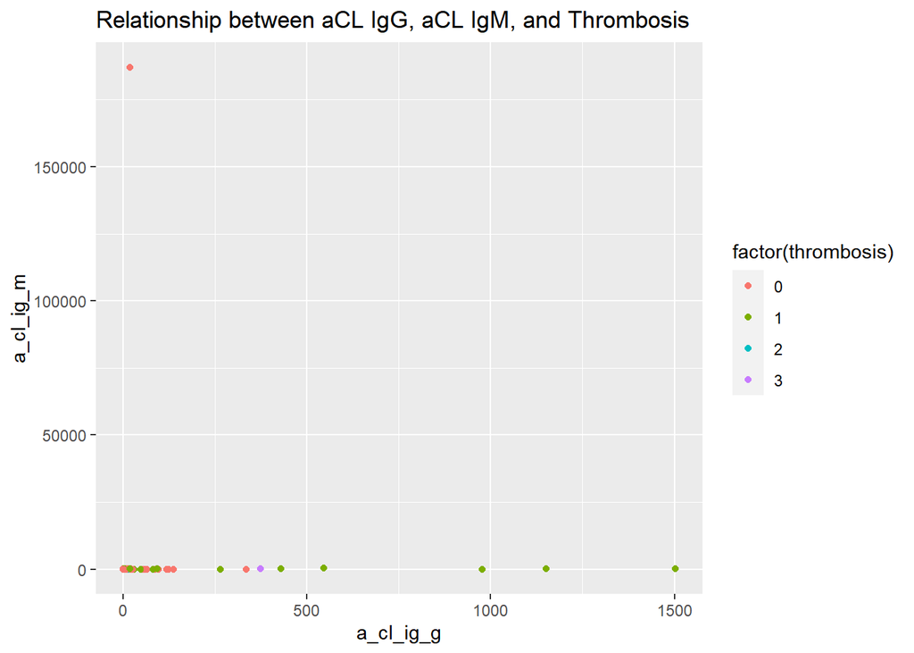

```r
# Examine the correlation between lab test results (a_cl_ig_g, a_cl_ig_m, ana) and thrombosis occurrence

# Plot the relationship between a_cl_ig_g, a_cl_ig_m, and thrombosis
library(ggplot2)
ggplot(tidy_data, aes(x=a_cl_ig_g, y=a_cl_ig_m, color=factor(thrombosis))) +
  geom_point() +
  labs(title="Relationship between aCL IgG, aCL IgM, and Thrombosis")
```

```r
# Compute the correlation coefficients between lab test results and thrombosis
cor_matrix <- cor(tidy_data[, c("a_cl_ig_g", "a_cl_ig_m", "ana", "thrombosis")], use="complete.obs")
print(cor_matrix)
```

```
##               a_cl_ig_g    a_cl_ig_m          ana  thrombosis
## a_cl_ig_g   1.000000000 -0.002347644 -0.003883356  0.16983423
## a_cl_ig_m  -0.002347644  1.000000000 -0.017696245 -0.02625659
## ana        -0.003883356 -0.017696245  1.000000000  0.15065545
## thrombosis  0.169834226 -0.026256590  0.150655452  1.00000000
```

phase 2